# Durational patterns in Northern Estonian and Northern Finnish - ScienceDirect

- View **PDF**

## Figures (4)

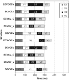

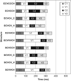

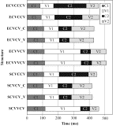

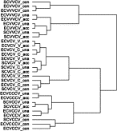

## [Journal of Phonetics](https://www.sciencedirect.com/journal/journal-of-phonetics)

[Volume 41, Issue 1](https://www.sciencedirect.com/journal/journal-of-phonetics/vol/41/issue/1), January 2013, Pages 1-16

# Durational patterns in Northern Estonian and Northern Finnish

[KariSuomi<sup>a</sup>](https://www.sciencedirect.com/science/article/pii/S009544701200068X?casa_token=l8l0Abr8NWsAAAAA:PwH7vJqfdkpUV4LgcIiX30e32zFYvxtwlXb28v5w7ejQrQc7XiUemImrfvvwToz-FMfHNw8Afg#!)[EinarMeister<sup>b</sup>](https://www.sciencedirect.com/science/article/pii/S009544701200068X?casa_token=l8l0Abr8NWsAAAAA:PwH7vJqfdkpUV4LgcIiX30e32zFYvxtwlXb28v5w7ejQrQc7XiUemImrfvvwToz-FMfHNw8Afg#!)[RiikkaYlitalo<sup>a</sup>](https://www.sciencedirect.com/science/article/pii/S009544701200068X?casa_token=l8l0Abr8NWsAAAAA:PwH7vJqfdkpUV4LgcIiX30e32zFYvxtwlXb28v5w7ejQrQc7XiUemImrfvvwToz-FMfHNw8Afg#!)[LyaMeister<sup>b</sup>](https://www.sciencedirect.com/science/article/pii/S009544701200068X?casa_token=l8l0Abr8NWsAAAAA:PwH7vJqfdkpUV4LgcIiX30e32zFYvxtwlXb28v5w7ejQrQc7XiUemImrfvvwToz-FMfHNw8Afg#!)

https://doi.org/10.1016/j.wocn.2012.09.001[Get rights and content](https://s100.copyright.com/AppDispatchServlet?publisherName=ELS&contentID=S009544701200068X&orderBeanReset=true)

## Abstract

Estonian and Finnish are closely related languages in which quantity is extensively exploited for lexical and grammatical purposes (in both consonants and vowels, independent of each other), yet with several phonological differences between the quantity systems (e.g. a ternary opposition in Estonian, a binary one in Finnish). To date, segment durations in the two languages have not been systematically compared. This paper reports a necessarily explorative experiment with two primary goals: first, to compare the phonetic realisation of quantity in the two languages in selected word structures, and second, to relate the results on accentual lengthening to the predictions of a speech timing framework (White, 2002) that has been developed on the basis of observations in an essentially non-quantity language, namely English. It was observed, besides cross-language differences in the durational realisation of the three-way and two-way quantity contrasts that durationally C<sub>1</sub>, outside the quantity system in both languages, behaves differently in the two languages. It was also observed that the patterns of accentual lengthening in the two languages are highly consistent with predictions of the timing framework.

### Highlights

► First larger-scale durational comparison of Estonian (E) and Finnish (F). ► Word structures with only short segments are highly alike in the two languages. ► Among non-short segments, F durations intermediate between E Q2 and Q3 categories. ► Durational behaviour of C<sub>1</sub>, outside the quantity system, different in E and F. ► Accentual lengthening in E and F consistent with a timing model developed for English.

## 1. Introduction

Lehiste (1965, p. 449) noted that “[t]he Finnish [quantity] system is essentially very simple. The problem in Estonian is much more complicated”. Since this is the case, we only discuss the situation in disyllabic word structures. Numerous phonological interpretations of the Estonian system have been offered; see e.g. the collection of papers in Lehiste and Ross (1997). Phonetically, there is a ternary opposition associated with the primarily stressed syllable, realised by durational relationships in the stressed syllable and in the following unstressed syllable; in loanwords, primary stress may be associated with a non-initial syllable. On the basis of this disyllabic sequence, disyllabic and longer words have one of three quantities, namely Q1, Q2 or Q3, traditionally called short, long and overlong. The three quantities are partly signalled by either the duration of the stressed-syllable vowel or the following consonant, or both, depending on word type. Theoretically, there seem to be nine possible combinations of short, long and overlong vowels and short, long and overlong consonants, i.e. 1+1, 1+2, 1+3; 2+1, 2+2, 2+3; 3+1, 3+2, 3+3 (where “1”=short, “2”=long and “3”=overlong; alternatively, these combinations could be given e.g. as VC, VCC, VC:C; VVC, VVCC, VVC:C, etc. However, the combinations 3+2 and 3+3 do not exist, so there are only seven combinations,<sup>1</sup> namely 1+1, 1+2, 1+3; 2+1, 2+2, 2+3; 3+1. For phonetic transcriptions of our Estonian example target words see below.

In Estonian, in contrast to Finnish, a vowel quantity opposition is not possible in unstressed syllables, and the duration of the vowel in the unstressed syllable following the stressed syllable is partly predictable: it is longer in Q1 words than in Q2 and Q3 words. Moreover, there are also tonal cues that distinguish among the three quantities (see below). Perceptual experiments have shown that native speakers of Estonian cannot distinguish between Q2 and Q3 on the basis of the stressed syllable alone: information on the second syllable is also necessary to perceptually distinguish between Q2 and Q3 (Eek and Meister, 1997, Eek and Meister, 2003). For such reasons, we endorse the nowadays dominant view that the proper scope of interpreting the Estonian ternary quantity contrast is the disyllabic sequence consisting of the stressed syllable and the next one; Hint (1997) is one of the scholars who still insist that the domain of Estonian quantity is the stressed syllable only. In unstressed syllables there is no vowel quantity contrast, whereas a binary consonant contrast for stop consonants is possible, also in the word-final position e.g. *pered* [ˑpereˑt] ‘family, pl. nom’ and *peret* [ˑpereˑtː] ‘family, sg. part.’. For more details see e.g. Lehiste, 1965, Lehiste, 1997 and Meister and Meister (2011).

To date, similarities and differences in the phonetic realisation of quantity in the two languages have not been systematically studied, although some impressionistic observations are available.<sup>2</sup> Consequently, our experiment was by necessity very exploratory in nature. Our first goal was to compare the two languages in this respect, by looking at two sets of disyllabic words in which either the stressed-syllable vowel or the following consonant carries the main burden of signalling the quantity contrasts, together with the predictable duration of the next, unstressed syllable (although there is a quantity opposition in the vowel in the unstressed syllable following the stressed one in Finnish, the duration of the single vowel in the second syllable of disyllabic words is predictable from the weight of the first syllable in many varieties, including Northern Finnish).

For Estonian, it has been repeatedly reported that the quantity degrees Q1, Q2 and Q3 are signalled also tonally, in addition to the durational differences, see e.g. Lippus (2011) and Lippus, Pajusalu, and Allik (2009) and the references therein. In this paper, however, we only report on the complex durational differences, and will look at the durational and tonal interplay in a subsequent paper.

Our second goal was to relate the results to the speech timing framework proposed by White, 2002, White,, a framework developed on the basis of experiments in English. Suomi (2009) reviewed his and his colleagues' research on Northern Finnish speech timing against White's framework, and concluded that “it is noteworthy that a timing model based on English is so consistent with observations in a full-fledged quantity language like Finnish, in which, in addition to postlexical effects on segment durations presumably operative in any language, lexical quantity differences […] in both vowels and consonants also exist”. The present materials enabled a highly controlled cross-linguistic comparison of accentual lengthening in two quantity languages, and the first application of White's framework to Estonian. Given the differences in the quantity systems of Estonian and Finnish, it was by no means *a priori* clear whether or not Estonian would exhibit similar consistency with the framework.

Below, we will first present all the results of the Estonian–Finnish comparison, including accentual lengthening, and only then return to accentual lengthening in the light of White's timing framework.

## 2. The experiment

### 2.1. Methods

#### 2.1.1. Choice of quantity oppositions to be compared

Lehiste (1965) calculated the numbers of possible word structures distinguished by quantity patterns only in Estonian and in Finnish. The number of disyllabic word structures, including structures that are differentiated by the presence and absence of a word-initial consonant, or by the presence and absence of a word-initial consonant, is 42 in Estonian and 32 in Finnish. Given these figures, exhaustive comparison of the quantity distinctions in a single experiment would be practically impossible. In this initial study we therefore chose to compare the realisation of quantity in two sets of Estonian disyllabic word structures and in their closest Finnish equivalents; of course, the Estonian ternary contrast must by necessity be compared with the Finnish binary one. In the first set of word structures, the Estonian three-way Q1–Q2–Q3 opposition is durationally realised mainly by the stressed-syllable vowel and the vowel in the next syllable while the intervening consonant is contrastively short, as in the triplet *kilu* [kiluˑ] (Q1) ‘sprat’, *kiilu* [kiːlu] (Q2) ‘wedge, gen. sg.’, *kiilu* [kiːˑlŭ] (Q3) ‘wedge, part. sg.’ Where no further specification is given in either language, the word form represents the uninflected base form, nominative singular; in the sort of target words used here, Q3 only occurs in inflected forms. The segmentally closest Finnish equivalents are *kela* [kelaˑ] (CVCV) ‘coil’ and *kiila* [kiːla] (CVVCV) ‘wedge’. We occasionally call the set including these example words the V-set. In the second set of word structures, the C-set, the stressed-syllable vowel is short and the word-level Q1–Q2–Q3 opposition is mainly carried by the following consonant and the vowel in the second syllable, as in the triplet *lugu* [lukuˑ] (Q1) ‘story’, *luku* [lukːu] (Q2) ‘lock, gen. sg.’, *lukku* [lukːˑu] (Q3) ‘lock, part. sg.’. Note that, in Estonian orthography, the letters 〈bdg〉 do not denote voiced plosives but short voiceless Q1 plosives, and that, intervocalically, 〈ptk〉 denote voiceless long (Q2) plosives. The closest Finnish equivalents are *luku* [lukuˑ] (CVCV) ‘number’ and *lukko* [lukːo] (CVCCV) ‘lock’.

At a level of abstraction at which segments are represented as either C or V, Estonian disyllabic Q1 words like *kilu* (from the V-set) and *lugu* (from the C-set) are structurally identical (for more example words see Table 1); they are CVCV words in which all segments are phonologically short. Structurally, they correspond to Finnish CVCV words like *kela* and *luku* that consist of phonologically single segments only. The sort of disyllabic Estonian Q2 and Q3 words exemplified above are structurally of two kinds. To reflect the difference in the respective phonological interpretations, we use for words like *kiilu* (Q2) and *kiilu* (Q3) the notations CVVCV and CVVVCV, respectively, and for words like *luku* (Q2) and *lukku* (Q3) the notations CVCCV and CVCCCV, respectively. Actually we would prefer the notations CVV:CV and CVC:CV for the Q3 words to indicate the interpretation that in both languages there are segmental V vs. VV and C vs. CC oppositions (one vs. two identical phonemes) and that, in addition, Estonian has the non-segmental opposition between Q2 and Q3 words, indicated by “:” in the Q3 words as suggested in Eek and Meister (1998). But for typographical reasons we have chosen to use the notations CVVVCV and CVCCCV instead. However, these latter notations do not imply any claim on our part that these structures contain three consecutive identical [phonemes](https://www.sciencedirect.com/topics/social-sciences/phoneme). Besides using the labels Q1, Q2 and Q3, we also use the tradition terms short, long and overlong, respectively.

Table 1. The target words used in the experiment.

[output not shown]

In this study we look at Estonian and Finnish disyllabic words consisting of two consecutive consonant–vowel sequences, words in which either the stressed-syllable vowel or the following consonant are mainly responsible for the phonetic realisation of quantity together with the duration of the next-syllable vowel duration. The syllabic affiliation of the consonant following the stressed-syllable vowel varies according to word structure. In both Estonian and Finnish, an intervocalic (phonetically short, Q1 or single) C is always the onset of the second syllable, i.e. preceded by a syllable boundary. In Estonian Q2 consonants (short geminates) and in Finnish double consonants the first component forms the coda of the first syllable and the second component forms the onset of the second syllable. In Estonian Q3 consonants (long geminates), finally, the first syllable is closed by the first, overlong component and the second, short component forms the onset of the second syllable. What this means is that, in the present target words, the second syllable always starts with a short (single) consonant, and that the first syllable may or may not end in a consonant. For this reason, it is not possible to state that we look at words with two consonant–vowel syllables (because the medial consonant may or may not be part of the first syllable).

The word structures here studied only represent a subset of the existing disyllabic word structures with contrasting quantity patterns in the two languages. Of the Estonian vowel and consonant combinations in disyllabic feet our C-set of target words includes the combinations 1+1, 1+2 and 1+3 (or VC, VCC and VCCC), and the V-set includes the combinations 1+1, 2+1 and 3+1 (or VC, VVC and VVVC). And our Finnish target words do not include the possible structures with a double vowel in the second syllable.

#### 2.1.2. Participants

Speech recordings were made of nine volunteer female speakers aged 20–54 years in both languages, the Estonian speakers in Tallinn and the Finnish speakers in Oulu. All speakers were currently or had earlier been university students without any known hearing or speaking disorders. The Estonian speakers (all, except one, with a non-linguistic background, employees of Tallinn University of Technology, age range 20–54, mean 34) represent the Northern variety of Standard Spoken Estonian (SSE), the Finnish speakers (all students of logopedics, age range 20–24, mean 22) represent the Northern variety of Standard Spoken Finnish (SSF). For Finnish, at least, the exact definition of the variety represented by the speakers is important; Ylitalo (2009) has shown systematic and at places extensive durational differences between the Northern (more exactly: Oulu) variety and two other local varieties of SSF. In SSE local varieties have not been as systematically investigated (but see Lippus, 2011, Lippus and Pajusalu, 2009), but for future reference, we wanted to study a particular variety of SSE.

#### 2.1.3. Materials

The starting point of target word selection was the existence of triplets of segmentally identical disyllabic words in the quantities Q1, Q2 and Q3 in the Estonian lexicon, representing the structures CVCV, CVVCV and CVVVCV on the one hand and the structures CVCV, CVCCV and CVCCCV, on the other. From such existing word triplets, we excluded those Estonian triplets for which segmentally sufficiently close Finnish equivalents do not exist. For example, Estonian has the triplet *nari* (Q1 or CVCV), *narri* (Q2 or CVCCV) and *narri* (Q3 or CVCCCV) and while also Finnish has *narri* (CVCCV), no sufficiently close equivalent to *nari* exists. All Finnish target words are uninflected (nom.sg.) nouns. Also the majority of the Estonian target words are nouns, but by necessity many of them are inflected noun or verb forms (since, as already mentioned, only inflected Q3 words are possible in the sort of disyllabic words investigated). The target words used in the experiment, all with word stress on the initial syllable, are shown in Table 1.

In the word sets in Table 1, it was not always possible to match the Estonian words with Finnish words that have the vowels that are the closest equivalents to the Estonian ones (and for Estonian /ɤ/, Finnish has no equivalent). However, we insisted on fully controlling consonant identity. In Finnish, it has been repeatedly observed that vowel identity has little effect on vowel duration. Lehtonen (1970) measured vowel durations in two nonsense word structures, pVVpV and pVppVV, embedded in a constant carrier sentence and spoken by 10 speakers. Each of the eight vowel phonemes thus occurred single and double in two word positions (first or second syllable). Lehtonen reported (p. 66) only eight statistically significant differences (*p*≤0.05) among the total of 112 comparisons. Except for the comparison /i/ - /u/, the significant differences always involved single vowels differing from each other with respect to Vowel Height (in five significant comparisons the difference was between high and low vowels, in the direction compatible with cross-linguistic generalisations). Similarly Suomi (2009) failed, by and large, to observe durational differences between /ɑ/, /æ/ and /o/ in altogether 18 comparisons in which a difference could have been observed in fully controlled consonantal contexts (with the unexplainable exception in the V<sub>2</sub> position of all three CVCV type words in which /ɑ/ had a longer duration than /o/). It seems, then that vowel duration in Finnish is determined not so much by vowel identity but by structural position, a circumstance not surprising in a quantity language. All Finnish vowel phonemes can occur as single or double (V or VV), and it is this difference that matters most in a given structural position, rather than intrinsic duration. The Finnish equivalents to the Estonian target words do not contain vowels that have been reported to differ durationally from the vowels that are the closest equivalents of the Estonian vowels. For example, an /i/ in an Estonian word set is never represented by /u/ or /ɑ/ in the respective Finnish words. As a result of the selection criteria of the Finnish words, we believe the target words in the two languages to resemble each other qualitatively as closely as is possible in a comparison of two different languages, using existing words.

Meaningful carrier sentences were constructed separately for each target word. The sentences were constructed to be relatively short to increase the probability that they would be spoken as a single intonation group, and without pauses. The target word always occurred in mid-sentence position to avoid any boundary-related durational effects. Each target word occurred with three degrees of accentuation, namely unaccented, accented and contrastively accented; “accented” here refers to what Suomi et al. (2008) named thematic accent. These same three degrees of accentuation, whether or not corresponding accentual categories exist in e.g. English, were elicited and found to be phonetically distinct in Suomi, Toivanen, and Ylitalo (2003).

The degrees of accentuation were elicited by using written context sentences imagined to precede the test sentences. For example, for the Finnish target word *kela* ‘coil’ the imagined context sentence intended to elicit an unaccented version was “*Sanoitko, että uusi kela **hajosi**?*” (‘Did you say that the new coil **was broken**?), and the test sentence was “*Sanoin, että uusi kela **katosi**.*” (‘I said that the new coil **disappeared**.’). Accordingly, there should be contrastive accent on *katosi* ‘disappeared’ and no accent on the target word. The context sentence intended to elicit the accented version was “Mitä sanoit?” (‘What did you say?’), and the test sentence was the same as before, but this time without any bold face. This time the target word is new information and should accordingly be accented. The context sentence intended to elicit the contrastively accented version, finally, was preceded by the context sentence “*Sanoitko, että uusi **kello** katosi?*” (‘Did you say that the new **clock** disappeared?’) and the test sentence was “*Sanoin, että uusi **kela** katosi.*”. But now a contrastive accent should fall on the target word (contrasting *coil* with *clock*). Thus the test sentence was always verbatim the same, and differences in accentuation were elicited by the context sentences. The Estonian sentences were constructed in the corresponding manner. For example, for the target word *kilu* ‘sprat’ the test sentence was “*Ütlesin, et väike kilu **küpsetati**.*” (‘I said that the little sprat was **fried**’), and the context sentences were “*Kas sa ütlesid, et väike kilu **keedeti**?*” (‘Did you say that the little sprat was boiled?’), “*Mida sa ütlesid?*” (‘What did you say?’) and “*Kas sa ütlesid, et väike **kala** küpsetati?*” (‘Did you say that the little **fish** was fried?’). For Estonian, there were 21 target words (the C-set)+21 target words (the V-set)=altogether 42 target words. With three degrees of accentuation, there were 3×42=126 sentences. For Finnish, there were 14 target words (the C-set)+14 target words (the V-set)=altogether 28 target words, and thus 84 sentences.

In principle, the carrier sentences could have been made even shorter by having the target word occur immediately after the conjunction *että* (‘that’) to further the likelihood that the sentences would be produced as a single prosodic unit. But in Suomi et al. (2003) the target word directly followed *että* in Experiment 1 and the authors observed that there was a 20 Hz step-up from *että* to the following unaccented version of the target word. In Experiment 2 a content word was placed between *että* and the target word and the step-up vanished from the target word but appeared in the added content word instead. So it appears that, at least in the sort of rather long sentences studied by Suomi et al. (2003), there is a prosodic boundary between *että* and the following word. To hopefully avoid such prosodic subdivision, a content word was always placed between *että* (in Estonian: *et*) and the target word.

For both languages a semi-randomised list of the test sentences was constructed in which a given target word never occurred in consecutive sentences, and in which no more than two consecutive sentences were intended to elicit the same degree of accentuation. To the beginning of the list of test sentences, six practice sentences similar to the test sentences were added, with two examples of each accent condition. The test sentences are shown in Appendix.

#### 2.1.4. Recordings

The Estonian and Finnish recordings took place in the recording studios of the Laboratory of Phonetics and Speech Technology, Tallinn University of Technology and Phonetics, University of Oulu, respectively. Both studios are equipped with high quality recording facilities: Audio-Technica ATM33a Cardioid Condenser Microphone, Mackie Onyx 1640 recording mixer, Adobe Audition 3.0 recording software on a Windows PC in Tallinn and a Sony ECM-88 Electret Condenser Lavalier Microphone, an M-Audio DMP3 Dual Microphone Preamplifier, a PC Wings PIII computer and an M-Audio Delta 1010 sound card, in Oulu. The talkers’ productions were recorded directly to hard disk (22.05 kHz, 16 bit).

An attempt was made to conduct the recordings at both places as similarly as possible. Each test sentence together with the associated context sentence (within parentheses) was presented to the speaker on a computer screen. The microphone was located below the midline between the speaker's head and the computer screen, about 20–25 cm from the speaker. The speaker controlled the speed of presentation by clicking a mouse. After saying a sentence, the speaker had to wait for 2 s before she could click for the next sentence. Before the recording started, the speaker was given the following instruction (in Estonian or Finnish):

On top of the computer screen you will see a sentence within parentheses. Imagine that your interlocutor speaks the parenthesised sentence to you. Read this sentence carefully. Then speak the non-parenthesised sentence at the bottom of the screen as if you were replying to your interlocutor. Speak the sentence in a way that would be appropriate after your interlocutor's sentence, in the imagined speaking situation. Try to avoid pauses, and if you detect that you have made an error, please say “Correction” and repeat the sentence.

The recordings were also monitored on-line from outside the recording studio, with a possibility of asking a speaker to repeat an erroneously produced sentence.

#### 2.1.5. Measurements

Six target words (0.3% of all target words) were rejected because the speaker produced contrastive accent on the wrong word (five instances) or another word was produced instead of the target word (one instance). The durational measurements were made by the first author using Praat (Boersma & Weenink, 2011). For each target word, the durations of all constituent segments (C<sub>1</sub>, V<sub>1</sub>, C<sub>2</sub> and V<sub>2</sub>) were measured, utilising displays of the waveform, broad-band spectrogram and auditory criteria. The onset of stop closure was determined as the moment at which the formants of the preceding vowel ceased, which was usually accompanied by simultaneous cessation of periodic oscillation. Burst portions of voiceless plosives were included in the duration of the consonant; with only occasional exceptions, the plosives in both languages were phonetically voiceless. This segmentation strategy has traditionally been adopted in Estonian and Finnish phonetics; for more details see Suomi (2009, p. 402). All authors inspected a random sample of 30 target words, and there was full agreement on the locations of the segment boundaries.

### 2.2. Results

The word structures will be referred to as ECVCCCV, ECVCCV, ECVCV_C, ECVVVCV, ECVVCV, ECVCV_V (the Estonian structures) and SCVCCV, SCVCV_C, SCVVCV, SCVCV_V (the Finnish structures). The notations ECVCV_C and ECVCV_V thus refer to the CVCV words that belong to the C-set and V-set, respectively (and similarly for the Finnish CVCV words). Because the C-set words were segmentally different from the V-set words, collapsing them at the outset seemed illegitimate.

For typographical reasons, the Finnish structures are referred to as SCVCCV, etc. rather than FCVCCV, etc. Example words of the set of structures ECVCCCV, ECVCCV, ECVCV_C, SCVCCV and SCVCV_C are *katte* (Q3), *kate* (Q2), *kade* (Q1), *katto* (CC), *katu* (C); the symbols in parentheses refer to the quantity of the words in Estonian, and to the quantity of the medial consonant in Finnish (single or double). Example words of the set of structures ECVVVCV, ECVVCV, ECVCV_V, SCVVCV, and SCVCV_V are *kiilu* (Q3), *kiilu* (Q2), *kilu* (Q1), *kiila* (VV), and *kela* (V). Means of C<sub>1</sub>, V<sub>1</sub>, C<sub>2</sub> and V<sub>2</sub> durations were computed for each speaker across all the words representing a given structure.

The grouping variables were usually Structure (one of the 10 structures mentioned in the preceding paragraph) and Prominence (unaccented, thematically accented or contrastively accented). For brevity, “accented” will be used instead of “thematically accented”. Note that the variable Language is coded in the variable Structure as six of the structures are Estonian and four are Finnish. Therefore, analyses of variance (ANOVAs) were usually made with Prominence as the within-structures repeated measure and Structure as the between-structures factor. Occasionally, however, analyses were made with Language as the between-structures factor. Note that since Structure and Language are not orthogonal, they cannot be used as factors in the same analysis. Segment Position was used as an additional variable (as explained in Section 2.2.2). Where applicable, Tukey HSD post-hoc tests were used.

#### 2.2.1. Segment durations

Notice that the symbols C<sub>1</sub>, V<sub>1</sub>, C<sub>2</sub> and V<sub>2</sub> here represent the four phonetic segments of the target words in both languages, irrespective of their phonemic composition (but C<sub>1</sub> always denotes a single phoneme, as does V<sub>2</sub>). Thus e.g. the first-syllable V as in CVCCV and the first-syllable VV in CVVCV are both denoted as V<sub>1</sub>. This is not to be confused with the more usual practice in which e.g. the Finnish structure CVCCV is given as C<sub>1</sub>V<sub>1</sub>C<sub>2</sub>C<sub>3</sub>V<sub>2</sub> to represent its abstract phonemic structure.

It may be worth mentioning that, originally, we made the durational comparisons using segment durations proportional to total word durations, one motivation for such a procedure being that it effectively controls for eventual cross-language differences in mean speaking rate. However, after scrutinising the results so obtained we noticed that the procedure may conceal important differences in segment durations. Consequently, we decided to make the comparisons using absolute durations.

The results of the raw durational measurements are shown in Table 2, and in Fig. 1, Fig. 2, Fig. 3. We only occasionally comment on the well-documented differences of segmental durations due to quantity within each of the two languages; our emphasis is on the hitherto little studied cross-linguistic differences.

Table 2. Mean segment durations (in ms) in the three degrees of prominence (“una”=unaccented, “acc”=accented, “con”=contrastively accented). Standard deviations in parentheses.

| Structure | C<sub>1</sub> una | C<sub>1</sub> acc | C<sub>1</sub> con | V<sub>1</sub> una | V<sub>1</sub> acc | V<sub>1</sub> con | C<sub>2</sub> una | C<sub>2</sub> acc | C<sub>2</sub> con | V<sub>2</sub> una | V<sub>2</sub> acc | V<sub>2</sub> con |
| --- | --- | --- | --- | --- | --- | --- | --- | --- | --- | --- | --- | --- |
| ECVCCCV | 56 (7) | 53 (6) | 85 (24) | 73 (9) | 69 (6) | 86 (12) | 155 (24) | 154 (19) | 210 (38) | 67 (12) | 53 (8) | 79 (15) |
| ECVCCV | 64 (9) | 61 (6) | 92 (16) | 76 (8) | 70 (7) | 86 (12) | 132 (16) | 112 (12) | 177 (32) | 71 (14) | 74 (15) | 106 (26) |
| ECVCV_C | 67 (6) | 65 (9) | 108 (22) | 75 (9) | 72 (8) | 95 (16) | 66 (10) | 65 (7) | 83 (13) | 100 (19) | 90 (18) | 145 (33) |
| ECVCV_V | 67 (5) | 69 (7) | 114 (21) | 73 (10) | 70 (7) | 94 (19) | 53 (9) | 53 (7) | 64 (8) | 104 (18) | 99 (18) | 157 (36) |
| ECVVCV | 75 (8) | 79 (6) | 111 (17) | 147 (20) | 144 (23) | 232 (41) | 52 (6) | 55 (4) | 65 (9) | 80 (11) | 83 (15) | 101 (20) |
| ECVVVCV | 74 (5) | 78 (8) | 114 (21) | 170 (27) | 171 (28) | 234 (44) | 56 (7) | 58 (4) | 67 (8) | 70 (12) | 60 (11) | 93 (20) |
| SCVCCV | 79 (15) | 79 (10) | 109 (24) | 67 (12) | 73 (12) | 98 (12) | 131 (19) | 131 (17) | 187 (23) | 49 (3) | 45 (4) | 54 (5) |
| SCVCV_C | 75 (13) | 76 (10) | 105 (19) | 54 (6) | 64 (8) | 93 (11) | 74 (10) | 76 (8) | 92 (9) | 87 (10) | 92 (10) | 127 (10) |
| SCVCV_V | 83 (12) | 84 (11) | 114 (16) | 63 (12) | 63 (10) | 91 (10) | 68 (10) | 68 (8) | 81 (9) | 98 (8) | 103 (12) | 133 (12) |
| SCVVCV | 88 (13) | 91 (12) | 117 (17) | 131 (20) | 147 (27) | 226 (25) | 53 (10) | 55 (7) | 60 (6) | 53 (4) | 50 (8) | 58 (6) |

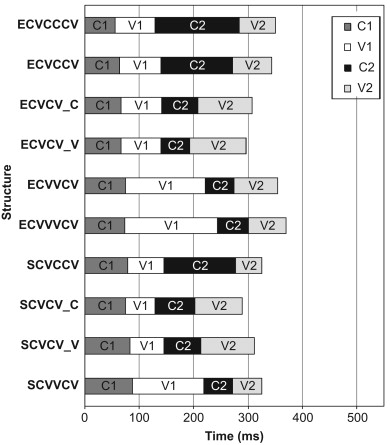

1. [Download : Download full-size image](https://ars.els-cdn.com/content/image/1-s2.0-S009544701200068X-gr1.jpg)

Fig. 1. Mean absolute segment durations (ms) in the unaccented word structures.

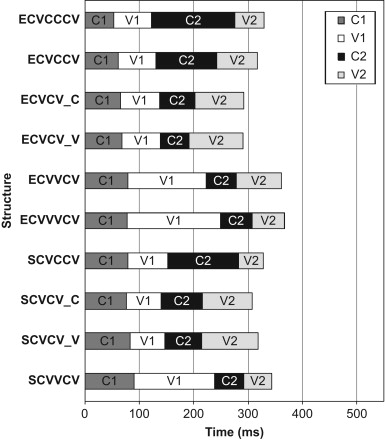

1. [Download : Download full-size image](https://ars.els-cdn.com/content/image/1-s2.0-S009544701200068X-gr2.jpg)

Fig. 2. Mean absolute segment durations (ms) in the accented word structures.

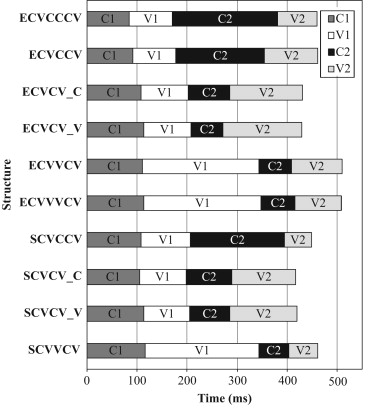

1. [Download : Download full-size image](https://ars.els-cdn.com/content/image/1-s2.0-S009544701200068X-gr3.jpg)

Fig. 3. Mean absolute segment durations (ms) in the contrastively accented word structures.

However, before proceeding to the results on the individual segments, let us present some summary information. It is customary, in Estonian phonetics, to summarise durational measurements in the CVCV (Q1), CVVCV (Q2) and CVVVCV (Q3) words by computing the following durational ratios: V<sub>1</sub>/V<sub>2</sub>, V<sub>1</sub>/C<sub>1</sub> and V<sub>2</sub>/C<sub>2</sub>. We computed such ratios (shown in Table 3), also for the Finnish CVCV and CVVCV words, because corresponding previous data are available both in Estonian, in Meister (2011, p. 114, Table 34) in which prominence was not manipulated, and in Northern Finnish, in Suomi (2007, p. 44, Tables 1 and 2) in which only unaccented and contrastively accented words were elicited. We wanted to check whether or not our results are in agreement with previous ones. We did not compute durational ratios for the C-set words because corresponding data are not available in Northern Finnish.

Table 3. The computed durational ratios V<sub>1</sub>/V<sub>2</sub>, V<sub>1</sub>/C<sub>1</sub> and V<sub>2</sub>/C<sub>2</sub> in the V-set words in the three degrees of prominence and, for comparison, Estonian data from Meister (2011) in which prominence was not manipulated and Finnish data from Suomi (2007) in which two degrees of prominence were investigated.

|  |  | una V<sub>1</sub>/V<sub>2</sub> | una V<sub>1</sub>/C<sub>1</sub> | una V<sub>2</sub>/C<sub>2</sub> | acc V<sub>1</sub>/V<sub>2</sub> | acc V<sub>1</sub>/C<sub>1</sub> | acc V<sub>2</sub>/C<sub>2</sub> | con V<sub>1</sub>/V<sub>2</sub> | con V<sub>1</sub>/C<sub>1</sub> | con V<sub>2</sub>/C<sub>2</sub> | Meister (2011) V<sub>1</sub>/V<sub>2</sub> | Meister (2011) V<sub>1</sub>/C<sub>1</sub> | Meister (2011) V<sub>2</sub>/C<sub>2</sub> |
| --- | --- | --- | --- | --- | --- | --- | --- | --- | --- | --- | --- | --- | --- |
| Estonian | Q1 | 0.70 | 1.09 | 1.96 | 0.71 | 1.01 | 1.87 | 0.60 | 0.82 | 2.45 | 0.7 | 1.0 | 1.8 |
|  | Q2 | 1.84 | 1.96 | 1.54 | 1.73 | 1.82 | 1.51 | 2.30 | 2.09 | 1.55 | 1.7 | 1.7 | 1.5 |
|  | Q3 | 2.43 | 2.30 | 1.25 | 2.85 | 2.19 | 1.03 | 2.52 | 2.05 | 1.39 | 2.8 | 2.2 | 1.0 |
| Finnish | V | 0.64 | 0.76 | 1.44 | 0.61 | 0.75 | 1.51 | 0.68 | 0.80 | 1.64 | – | – | – |
|  | VV | 2.47 | 1.49 | 1.0 | 2.94 | 1.62 | 0.91 | 3.90 | 1.93 | 0.97 | – | – | – |
| Suomi (2007) | V | 0.64 | 0.76 | 1.17 | – | – | – | 0.70 | 0.75 | 1.34 | – | – | – |
|  | VV | 2.43 | 1.45 | 0.84 | – | – | – | 3.77 | 1.77 | 0.84 | – | – | – |

It can be seen in Table 3 that our Estonian ratios, especially those computed from the accented words, are very much like Meister's ratios, and that, similarly, our Finnish ratios are close to those reported by Suomi. We therefore conclude that our materials are properly representative of the two languages.

##### 2.2.1.1. C<sub>1</sub> duration

Effects of Structure on C<sub>1</sub> duration were not expected, and none were observed apart from an effect relatable to the difference in the identities of the initial consonants in the two sets of target words (the C-set and the V-set). We therefore examined the effect of Language instead (in addition to that of Prominence). Prominence had an effect on C<sub>1</sub> duration [*F*(1, 88)=283.98, *p*<0.001], as did Language [*F*(1, 88)=21.05, *p*<0.001]. There was no interaction [*F*(1, 88)=3.11, n.s.]. Pairwise comparisons indicated that the duration of C<sub>1</sub> was longer in the contrastively accented words than in the accented and unaccented words (*p*<0.001), and that there was no difference between the latter two. In each degree of prominence, the duration of C<sub>1</sub> was longer in Finnish than in Estonian, see the left side columns of Table 4.

Table 4. Mean absolute and proportional duration of C<sub>1</sub> in the three degrees of prominence (“una”=unaccented, “acc”=accented, “con”=contrastively accented). Standard deviations in parentheses.

|  | Absolute (ms) Estonian | Absolute (ms) Finnish | Proportional (% of total word duration) Estonian | Proportional (% of total word duration) Finnish |
| --- | --- | --- | --- | --- |
| una | 67 (9) | 81 (14) | 20.1 (3) | 25.9 (3) |
| acc | 68 (11) | 82 (12) | 20.9 (3) | 25.4 (2) |
| con | 104 (22) | 111 (19) | 22.4 (4) | 25.4 (2) |

A potential explanation of the differences between the two languages in C<sub>1</sub> duration is that the mean speaking rate of the Estonian speakers was faster than that of the Finnish speakers. There would be little point in comparing the durations of the carrier sentences because the carrier sentences varied in many ways that might affect their total durations, which means that a systematic difference between the two languages would not necessarily prove that the mean speaking rates were different. As for total word durations, Language had an effect [*F*(1, 88)=4.09, *p*<0.05]: mean total word duration was 377 ms in Estonian, 358 ms in Finnish. If anything, this would rather suggest that the Finnish speakers' mean speaking rate was the faster one. We also computed mean proportional C<sub>1</sub> durations relative to total word duration (on the right side columns of Table 4). On these proportional durations, Prominence had an effect [*F*(1, 88)=10.17, *p*<0.001] as did Language [*F*(1, 88)=56.07, *p*<0.001], and there was an interaction [*F*(1, 88)=25.57, *p*<0.001]. In Estonian, Prominence had an effect [*F*(1, 53)=39.69, *p*<0.001], and post-hoc tests indicated that in fact all three degrees of prominence differed with respect to proportional C<sub>1</sub> duration despite the very small differences. In Finnish Prominence had no effect [*F*(1, 35)=1.63, n.s.]. We conclude that the observed difference in C<sub>1</sub> duration reflects a genuine difference between the two languages, even though “[t]he only one-to-one correspondence between the two quantity structures [= systems] is the quantity of word-initial consonants, which is non-contrastive in both Finnish and Estonian” (Lehiste, 1965, p. 450). Such differences are not unprecedented: Ylitalo (2009, p. 137) observed a similar difference among three local varieties of Standard Spoken Finnish: almost invariably, in both unaccented and contrastively accented sets of words, C<sub>1</sub> had a shorter mean duration in Oulu than in Turku and Tampere, the differences exceeding those predictable from differences in mean speaking rate.

##### 2.2.1.2. V<sub>1</sub> duration

In contrast to C<sub>1</sub>, V<sub>1</sub> participates in signalling the quantity contrasts, and large effects of Structure were expected. Prominence had an effect [*F*(1, 80)=329.29, *p*<0.001] as did Structure [*F*(9, 80)=108.22, *p*<0.001], and there was an interaction [*F*(9, 80)=18.19, *p*<0.001].

Among the unaccented words, Structure had an effect [*F*(9, 80)=66.79, *p*<0.001]. Post-hoc tests indicated that, predictably, all structures with a short/single V<sub>1</sub> differed from all other structures, and, less predictably, that they did not differ from each other. ECVVVCV and ECVVCV narrowly failed to differ from each other (*p*=0.059). SCVVCV had shorter V<sub>1</sub> duration than ECVVVCV, but did not differ from ECVVCV.

Among the accented words, Structure had an effect [*F*(9, 80)=61.74, *p*<0.001], and the post-hoc tests indicated exactly the same pattern as in the unaccented words; this time ECVVVCV and ECVVCV failed to differ from each other slightly less narrowly (*p*=0.067).

Among the contrastively accented words, finally, Structure had an effect [*F*(9, 80)=73.86, *p*<0.001], and the post-hoc tests showed that the structures with a short/single V<sub>1</sub>, which did not differ among themselves, once more had smaller V<sub>1</sub> duration than the other structures, which did not differ from each other. That is, ECVVCV, ECVVVCV and SCVVCV had statistically equal V<sub>1</sub> duration.

The V<sub>1</sub> durational difference in the Estonian ECVVCV–ECVVVCV opposition thus failed to reach significance in each degree of prominence but especially in the contrastively accented words. It can be seen in Table 2 that the standard deviations in these structures are large, especially in the contrastively accented words. Notice that in the Finnish structure SCVVCV the standard deviation is not largest in the contrastively accented words, as it is in ECVVCV and ECVVVCV. It is well known that the Estonian VV–VVV (or Q2–Q3) opposition is rather precarious durationally, and this seems to be especially true in the contrastively accented words, see the practically identical means in Table 2. But recall again that this opposition is also signalled tonally.

##### 2.2.1.3. C<sub>2</sub> duration

The words in the C-set and those in the V-set contain a different set of medial consonants, with presumably different mean intrinsic durations. This circumstance might cause differences that are not relevant here. For example, in the unaccented words, C<sub>2</sub> had a longer duration in SCVCV_C than in ECVVCV, SCVVCV and ECVCV_V. That is, a C-set structure had longer C<sub>2</sub> duration than three V-set structures, a difference that probably has nothing to do with how quantity is realised. To avoid discussing such irrelevant differences, we overlook any differences in C<sub>2</sub> duration between the C-set structures and the V-set structures.

Prominence had an effect on C<sub>2</sub> duration [*F*(1, 80)=219.82, *p*<0.001], as did Structure [*F*(9, 80)=121.60, *p*<0.001], and there was an interaction [*F*(9, 80)=13.38, *p*<0.001]. Among the unaccented words, Structure had an effect [*F*(9,80)=78.80, *p*<0.001], and post-hoc tests indicated that in all structures with a short/single medial consonant C<sub>2</sub> duration was smaller than in the remaining three structures. C<sub>2</sub> duration was longest in ECVCCCV and second longest in ECVCCV and SCVCCV which did not differ from each other.

Among the accented words, Structure had an effect [*F*(9, 80)=109.89, *p*<0.001], and post-hoc tests indicated that the structures with a short/single medial consonant did not differ among themselves. In all structures with a short/single medial consonant C<sub>2</sub> duration was smaller than in the remaining three structures whose order of magnitude was ECVCCV<SCVCCV<ECVCCCV.

Among the contrastively accented words, finally, Structure had an effect [*F*(9, 80)=85.06, *p*<0.001], and post-hoc tests indicated that the structures with a short/single medial consonant did not differ among themselves. In all structures with a short/single medial consonant C<sub>2</sub> duration was smaller than in the remaining three structures. ECVCCCV had longer C<sub>2</sub> duration than ECVCCV; SCVCCV did not differ from either.

To summarise, the binary or ternary oppositions C vs. CC vs. CCC were always maintained in both languages. SCVCCV had longer C<sub>2</sub> duration than ECVCCV in one degree of prominence, and shorter C<sub>2</sub> duration than ECVCCCV in two degrees of prominence. In a nutshell: EC<sub>2</sub>=SC<sub>2</sub><ECC<sub>2</sub>≤SCC<sub>2</sub>≤ECCC<sub>2</sub> (but ECC<sub>2</sub><ECCC<sub>2</sub>) (where “≤” means that there was a difference in at least one degree of prominence but not in all degrees of prominence). SCC<sub>2</sub> thus vacillated between ECC<sub>2</sub> and ECCC<sub>2</sub>.

##### 2.2.1.4. V<sub>2</sub> duration

Prominence had an effect on V<sub>2</sub> duration [*F*(1,80)=210.39, *p*<0.001] as did Structure [*F*(9,80)=36.41, *p*<0.001], and there was an interaction [*F*(9,80)=7.99, *p*<0.001]. Among the unaccented words, Structure had an effect [*F*(9,80)=22.51, *p*<0.001]. Post-hoc tests indicated that, for Estonian, the structures with a heavy initial syllable (ECVCCCV, ECVCCV, ECVVCV and ECVVVCV), which did not differ among themselves, had a shorter V<sub>2</sub> duration than the structures with a light initial syllable (ECVCV_C and ECVCV_V), which in turn did not differ among themselves. *Mutatis mutandis*, the same holds for the Finnish structures: SCVCCV and SCVVCV were not distinct from each other and had shorter V<sub>2</sub> duration than SCVCV_C and SCVCV_V which were not distinct from each other. As for cross-linguistic comparisons, V<sub>2</sub> duration in SCVCCV did not differ from that in ECVCCCV, and V<sub>2</sub> duration in SCVVCV did not differ from ECVCCCV, ECVVVCV and ECVCCV. SCVCV_C and SCVCV_V in turn did not differ from ECVVCV, ECVCV_C and ECVCV_V.

Among the accented words, Structure had an effect [*F*(9, 80)=25.60, *p*<0.001], and post-hoc tests indicated a complex pattern. This time the Estonian structures with a heavy initial syllable differed among themselves. ECVCCCV had a shorter V<sub>2</sub> duration than ECVCCV and ECVVCV, with ECVVVCV being non-distinct from ECVCCCV and ECVCCV (but differing from ECVVCV). For the Finnish structures, the results were statistically like those obtained for the unaccented words (see above). Cross-linguistically, V<sub>2</sub> duration in SCVCCV and in SCVVCV did not differ from that in ECVCCCV and in ECVVVCV, and SCVCV_C and SCVCV_V did not differ from ECVCV_C and ECVCV_V.

Among the contrastively accented words, Structure had an effect [*F*(9, 80)=25.69, *p*<0.001], and post-hoc test indicated that, in both languages, the structures with a heavy initial syllable did not differ among themselves and had a shorter V<sub>2</sub> duration than the structures with a light initial syllable, which did not differ among themselves. Statistically, this is exactly the same outcome as with the unaccented words. The cross-linguistic comparison yields a slightly different pattern. This time SCVCCV and SCVVCV did not differ from ECVCCCV (but did differ from the other Estonian structures with a heavy initial syllable). SCVCV_C and SCVCV_V did not differ from ECVCV_C and ECVCV_V.

Thus in both languages, it was a consistent finding that V<sub>2</sub> had a shorter duration after a heavy initial syllable than after a light one. The Estonian structures involved two degrees of at least phonetic heaviness of the initial syllables, namely those in the structures ECVCCV and ECVVCV (Q2 words) vs. ECVCCCV and ECVVVCV (Q3 words), the latter two being phonetically heavier than the former two. However, it was only in the accented words that some differences among Q2 and Q3 words emerged. Ignoring these latter patterns, what seems to matter is simply whether the initial syllable is light or heavy, not the degree of heaviness. In cases where there was no cross-linguistic difference in V<sub>2</sub> duration between Estonian and Finnish structures, the structures in question involved initial syllables with the same weight (i.e. both the Estonian and the Finnish structure had either a light or a heavy initial syllable), with one exception, namely when V<sub>2</sub> duration in SCVCV_C and SCVCV_V did not differ from V<sub>2</sub> duration in ECVVCV (in the unaccented words). Excluding this single exception, the results can be given in a nutshell as E(H)V<sub>2</sub>=S(H)V<sub>2</sub><E(L)V<sub>2</sub>=S(L)V<sub>2</sub> (where “(H)” and “(L)” mean a heavy and a light initial syllable, respectively). Turning now to the Prominence×Structure interaction in V<sub>2</sub> duration, it was again the case that the duration was always longer in the contrastively accented words than in the other words. In seven structures V<sub>2</sub> duration was not different in the unaccented and accented words (ECVCCV, ECVCV_C, ECVCV_V, ECVVCV, SCVCV_C, SCVCV_V and SCVVCV), and in three structures V<sub>2</sub> duration was longer in the unaccented words than in the accented words (ECVCCCV, ECVVVCV, SCVCCV).

#### 2.2.2. Accentual lengthening

As reported above, it was usually the case that segment durations were statistically non-distinct in the unaccented words and in the accented words, and longer in the contrastively accented words. For Finnish, these findings are in agreement with previous ones (Suomi et al., 2003). Therefore, accentual lengthening (LEN) was defined, for each segment in each structure, as the difference between the mean of the unaccented (UNA) and accented (ACC) segment and the duration of the contrastively accented (CON) segment, more precisely LEN=CON − (UNA+ACC)/2. From this measure proportional accentual lengthening (PropLen) was further calculated as the percentage of the lengthening of the mean of the unaccented and accented token, or PropLen=(LEN/(UNA+ACC)/2)×100. The values for both absolute and proportional accentual lengthening are shown in Table 5.

Table 5. Mean absolute and proportional accentual lengthening. Standard deviations in parentheses.

| Structure | C<sub>1</sub> | V<sub>1</sub> | C<sub>2</sub> | V<sub>2</sub> |
| --- | --- | --- | --- | --- |
| Absolute accentual lengthening (ms) |  |  |  |  |
| ECVCCCV | 30 (32) | 15 (15) | 55 (45) | 19 (27) |
| ECVCCV | 30 (26) | 13 (15) | 55 (41) | 34 (34) |
| ECVCV_C | 42 (32) | 22 (20) | 18 (16) | 50 (38) |
| ECVCV_V | 47 (30) | 22 (20) | 11 (14) | 55 (40) |
| ECVVCV | 33 (27) | 86 (51) | 12 (13) | 20 (31) |
| ECVVVCV | 38 (32) | 64 (50) | 10 (12) | 28 (32) |
| SCVCCV | 31 (27) | 28 (20) | 56 (33) | 7 (12) |
| SCVCV_C | 29 (31) | 34 (20) | 17 (17) | 39 (23) |
| SCVCV_V | 30 (22) | 27 (21) | 12 (15) | 33 (20) |
| SCVVCV | 27 (24) | 87 (49) | 6 (13) | 6 (14) |
| Proportional accentual lengthening (%) |  |  |  |  |
| ECVCCCV | 61 (71) | 22 (22) | 36 (29) | 33 (43) |
| ECVCCV | 52 (50) | 18 (20) | 46 (35) | 50 (54) |
| ECVCV_C | 67 (52) | 31 (27) | 28 (22) | 57 (50) |
| ECVCV_V | 72 (51) | 33 (34) | 22 (32) | 58 (46) |
| ECVVCV | 43 (33) | 64 (44) | 24 (32) | 28 (50) |
| ECVVVCV | 54 (50) | 39 (32) | 19 (30) | 48 (58) |
| SCVCCV | 52 (73) | 48 (46) | 46 (31) | 16 (28) |
| SCVCV_C | 43 (38) | 64 (46) | 24 (25) | 46 (35) |
| SCVCV_V | 38 (32) | 53 (47) | 24 (33) | 34 (21) |
| SCVVCV | 31 (30) | 70 (55) | 15 (28) | 16 (36) |

PropLen was investigated for potential effects of Structure, Language, and Segment Position or SegPos (i.e. C<sub>1</sub>, V<sub>1</sub>, C<sub>2</sub> and V<sub>2</sub>). As for the main effects, if Structure should have an effect, it would mean that different structures received different amounts of proportional accentual lengthening. If Language should have an effect, it would mean that the amount of proportional accentual lengthening was different in the two languages. If SegPos should have an effect, it would mean that segments in different word positions received different amounts of proportional accentual lengthening. In addition, many kinds of unpredictable interactions seemed conceivable.

Structure had no effect on PropLen [*F*<1] but SegPos did [*F*(3, 320)=12.38, *p*<0.001], and there was an interaction between Structure and SegPos [*F*(27, 320)=3.51, *p*<0.001]. The lack of a Structure effect implies that there was no difference between the two languages, but this was nevertheless separately confirmed: Language had no effect [*F*(1, 352)=1.13, n.s.] but SegPos again did [*F*(3, 352)=11.10, *p*<0.001] and there was an interaction between Language and SegPos [*F*(3, 352)=11.32, *p*<0.001]. These results thus show that all structures received the same amount of total proportional accentual lengthening, and that the amount of total proportional accentual lengthening was the same in both languages. But the interaction Language×SegPos indicates that there must be differences between the two languages with respect to the amounts of proportional accentual lengthening in the four segment positions (C<sub>1</sub>, V<sub>1</sub>, C<sub>2</sub> and V<sub>2</sub>). These interactions were explored by looking at the effects of Language on PropLen separately in each segment position.

Language had an effect on C<sub>1</sub>_PropLen (proportional lengthening of C<sub>1</sub>) [*F*(1, 88)=7.06, *p*<0.01]. Mean C<sub>1</sub>_PropLen was 58% for the Estonian speakers and 41% for the Finnish speakers. It is perhaps useful to clarify what is happening here. It was observed earlier (see Table 4) that C<sub>1</sub> always had systematically smaller proportional duration in Estonian than in Finnish. That is, C<sub>1</sub> occupied a smaller percentage of total word duration in Estonian than in Finnish. It was also observed that the proportional duration of C<sub>1</sub> varied as a function of prominence in Estonian, but not in Finnish. The third finding was that the proportional accentual lengthening of C<sub>1</sub> was larger in Estonian than in Finnish. Now the proportional duration of C<sub>1</sub> did not vary as a function of prominence in Finnish because, in this language, C<sub>1</sub> was lengthened statistically as much as the other segments on average. But in Estonian, proportional accentual lengthening of C<sub>1</sub> was larger than that of the other segments because C<sub>1</sub> was lengthened more than the other segments on average. That is, contrastive accent increased the proportional duration of C<sub>1</sub> in Estonian, but not in Finnish.

On V<sub>1</sub>_PropLen, Language had an effect [*F*(1, 88)=13.80, *p*<0.001], mean V<sub>1</sub>_PropLen being 34% for the Estonian speakers and 59% for the Finnish speakers. On C<sub>2</sub>_PropLen, however, Language had no effect [*F*<1]. On V<sub>2</sub>, finally, Language again had an effect [*F*(1, 88)=8.45, *p*<0.01], mean V<sub>2</sub>_PropLen was 46% for the Estonian speakers and 28% for the Finnish speakers.

The effects of Language on proportional accentual lengthening (PropLen) as a function of segment position (SegPos) are summarised in Table 6. It was observed that the Estonian speakers exhibited a larger proportional accentual lengthening than the Finnish speakers in segment positions C<sub>1</sub> and V<sub>2</sub>, and a smaller proportional lengthening than the Finnish speakers in segmental position V<sub>1</sub> (in position C<sub>2</sub> there was no difference) We wish to argue that these differences are connected to, and explainable by, differences in the respective quantity systems.

Table 6. Mean proportional accentual lengthening according to segment position. “=” means that the cross-linguistic difference failed to reach statistical significance. Standard deviations in parentheses.

|  | C<sub>1</sub> | V<sub>1</sub> | C<sub>2</sub> | V<sub>2</sub> |
| --- | --- | --- | --- | --- |
| Estonian | 58 (31) | 34 (25) | 29=(19) | 46 (33) |
| Finnish | 41 (28) | 59 (37) | 27=(18) | 28 (19) |

Speakers of Estonian may be more reluctant than speakers of Finnish to lengthen V<sub>1</sub> extensively because such lengthening might interfere with the durational signalling of the very complex quantity contrasts. Recall from above (Section 1.) that, in Estonian, the quantity relations among V<sub>1</sub> and C<sub>2</sub> yield seven different possibilities. In Finnish there are only four possibilities (VC, VVC, VCC, VVCC), and the V–VV contrast is supported in the initial syllable by a very robust durational difference; in the present study the durational VV/V ratio, in the SCVVCV and SCVCV_V structures (the V-set), was 2.1, 2.3 and 2.5 in the unaccented, accented and contrastively accented words, respectively. That is, accentual lengthening in fact increased the robustness of the VV/V ratio. In Estonian, the corresponding VV/V ratios, computed from the V-set of words, were 2.0, 2.1 and 2.5, but the VVV/VV ratios, similarly computed from the V-set, were 1.2, 1.2 and 1.0, respectively. That is, while the VV/V or Q2/Q1 ratios were similar to the Finnish VV/V ratio, the VVV/VV ratios were very small, and they were in fact decreased by accentual lengthening (but recall that the Estonian Q2–Q3 opposition is also signalled tonally, for references see below).

On the other hand, speakers of Northern Finnish must be careful not to lengthen V<sub>2</sub> too much, especially when the initial syllable is light, lest the second-syllable single V<sub>2</sub> be confused with a double vowel. In Northern Finnish, the difference between second-syllable single (V) and double vowel (VV) after a light initial syllable is rather precarious. For example, in Suomi and Ylitalo (2004, Table 2, p. 42), in which segment identities were fully controlled, the VV/V durational ratio measured in CV.CVV.CV and CV.CV.CV nonsense items was 1.5. Nakai, Kunnari, Turk, Suomi, and Ylitalo (2009) observed that utterance-final lengthening of V<sub>2</sub> after a light initial syllable was effectively blocked, obviously in order to prevent confusion with a double vowel in the same position. But speakers of Estonian may feel free to lengthen V<sub>2</sub> because there is no quantity opposition in the second syllable. And notice that there was no significant difference among the Estonian structures with respect to V<sub>2</sub>_PropLen; that is, all relative differences of V<sub>2</sub> duration, which are known to be important in distinguishing Q2 and Q3 words, were preserved also in the contrastively accented words.

We believe that these factors explain two of the differences in Table 6, namely the avoidance of extensive lengthening of V<sub>1</sub> in Estonian and of V<sub>2</sub> in Northern Finnish to preserve quantity distinctions, and the freedom to lengthen V<sub>2</sub> in Estonian without jeopardising the quantity distinctions. Given the fact that a word received a constant amount of accentual lengthening in both languages, it may be that the other differences in Table 6 simply follow.

The results in the C<sub>1</sub> position were fully unexpected. Nevertheless, they show that there is yet another way in which the word-initial consonant behaves differently in the two languages. In Estonian, this consonant has shorter absolute and proportional duration than in Finnish, its proportional duration varies as a function of prominence in Estonian but not in Finnish, and it was lengthened more extensively under contrastive accentuation in Estonian than in Finnish. C<sub>1</sub> is outside the quantity system in both languages, and it has been shown that, in Estonian, C<sub>1</sub> duration acts as a perceptual cue to local speaking rate (Eek and Meister, 2003, Meister, 2011, Meister and Meister, 2011). To our knowledge, the matter has not been investigated in Finnish.

As a way of summarising the results, a Clustering Analysis (using the complete linkage method that finds similar clusters) of the mean durations in Table 2 was made. That is, the mean durations of all four segments were observed in classifying the Structures. The results are shown in Fig. 4.

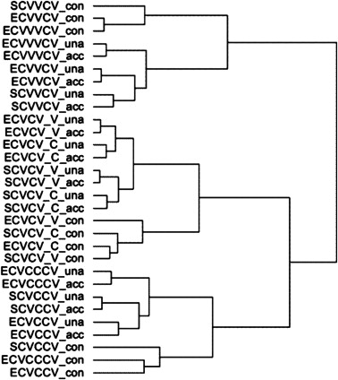

1. [Download : Download full-size image](https://ars.els-cdn.com/content/image/1-s2.0-S009544701200068X-gr4.jpg)

Fig. 4. A dendrogram showing the classification of the 10 Structures in the three degrees of prominence by a Cluster Analysis (complete linkage method) on the basis of the mean segment durations in Table 2 (“una”=unaccented, “acc”=accented, “con”=contrastively accented).

It can be seen that, first of all, the Structures with an (over)long/double V<sub>1</sub> (on top of Fig. 4) are separated from all other Structures. Among the Structures without an (over)long/double V<sub>1</sub>, the first division is between Structures having a short/single C<sub>2</sub> and Structures with an (over)long/double C<sub>2</sub> (bottom of Fig. 4). Within each of these three subgroups of Structures, the contrastively accented ones are separated from the Structures in the other two degrees of prominence. ECVVVCV (Q3) was separated from ECVVCV (Q2) and ECVCCCV (Q3) was separated from ECVCCV (Q2) in the unaccented and in the accented conditions, but not in the contrastively accented condition; otherwise the quantities were always separated in both languages. SCVVCV was always separated from ECVVVCV and ECVVCV, and SCVCCV was always separated from ECVCCCV and ECVCCV. Obviously the fact that the Estonian and Finnish CVCV structures always differed from each other (except for the contrastively accented versions) is due to the difference in C<sub>1</sub>, as there were no differences in the other segment positions.

#### 2.2.3. Confusion patterns

The clustering results shown in Fig. 4 were based on the mean segment durations in Table 2. In this section, we complement the picture by looking at the confusion patterns among the individual word tokens representing the Estonian and Finnish Structures, information that is not provided by the clustering analysis. For example, the clustering analysis shows that SCVVCV differs from both ECVVVCV and ECVVCV, and that SCVCCV differs from both ECVCCCV and ECVCCV, but are the two Finnish Structures closer to the Estonian Q3 Structures or the Q2 Structures? To get answers to such questions, an IBM SPSS Discriminant Analysis (with default settings) of the individual Structure tokens was performed, using Structure as the grouping variable and the absolute durations of C<sub>1</sub>, V<sub>1</sub>, C<sub>2</sub> and V<sub>2</sub> of each token as independent (predictor) variables. Discriminant analysis builds a predictive model for group membership based on linear combinations of the predictor variables that provide the best discrimination between the groups. That is, the discriminant analysis evaluated the durations of all four phonetic segments in each token to find the best discrimination between the word structures. For simplicity, the Estonian structures ECVCV_C and ECVCV_V were collapsed to form the structure ECVCV, and the Finnish structures SCVCV_C and SCVCV_V were similarly collapsed to SCVCV. Table 7 shows the results for all tokens. The analyses were also made separately for each degree of prominence, but there were no large differences due to prominence.

Table 7. Percent correct classifications of the tokens representing the eight word structures. ECVCV_C and ECVCV_V had been collapsed to obtain ECVCV, and SCVCV_C and SCVCV_V had been collapsed to obtain SCVCV.

|  |  | Classified as ECVCCCV | Classified as ECVCCV | Classified as ECVCV | Classified as ECVVCV | Classified as ECVVVCV | Classified as SCVCCV | Classified as SCVCV | Classified as SCVVCV |
| --- | --- | --- | --- | --- | --- | --- | --- | --- | --- |
| Original | ECVCCCV | 67.2 | 16.4 |  |  |  | 15.9 | 0.5 |  |
|  | ECVCCV | 11.6 | 53.4 | 7.4 |  |  | 9.0 | 18.5 |  |
|  | ECVCV |  | 2.4 | 62.2 | 0.3 |  | 1.3 | 33.9 |  |
|  | ECVVCV |  |  | 3.2 | 72.0 | 12.7 |  | 4.2 | 7.9 |
|  | ECVVVCV |  |  |  | 15.3 | 55.6 | 0.5 | 1.6 | 27.0 |
|  | SCVCCV | 17.0 | 12.2 | 0.5 |  |  | 62.8 | 5.9 | 1.6 |
|  | SCVCV |  | 8.0 | 33.8 |  | 0.3 |  | 57.9 |  |
|  | SCVVCV |  | 1.1 |  | 11.1 | 28.6 | 0.5 | 3.2 | 55.6 |

Looking first at the Estonian structures only, it can be seen that Q1 words and Q3 words were never confused with each other, but there were confusions between Q3 words and Q2 words as well as between Q2 words and Q1 words. However, the former confusions were more frequent than the latter: there were on average Q3–Q2 confusions in 14.0% of the cases and Q2–Q1 confusions in 3.3% of the cases. Among the Finnish structures, SCVCV words were never confused with words representing the other two Finnish structures, and all confusions among the Finnish structures were relatively rare (there were, on average, confusions among the Finnish structures in 2.8% of the cases). It can be concluded, expectedly, that the durational differences among the Finnish structures are more robust than the differences among the Estonian structures. This is not surprising, for two reasons. First, Finnish only has binary contrasts while Estonian has ternary contrasts. Second, it is well known that, in Estonian, tonal cues are additionally used to differentiate especially among Q2 and Q3 words, see e.g. Liiv, 1961; Lippus et al., 2009; Lippus, Pajusalu, and Allik, 2011.

As for cross-linguistic comparisons, ECVCV was mostly cross-linguistically confused with SCVCV and vice versa. Võrk (1972, p. 13) warns Finnish learners of Estonian against making the second-syllable vowel too short in Q1 words. This is an appropriate warning for speakers from e.g. the broad Häme dialect area (including Helsinki, the capital): as shown by Ylitalo (2009), for Tampere speakers (also belonging to the broad Häme dialect) V<sub>2</sub> in CVCV words has a much shorter duration than for speakers of Northern Finnish. The CVCV words of Northern Finnish are in fact durationally very much like Estonian CVCV words (apart from C<sub>1</sub>), as indicated by the present confusion results. The similarity of ECVCV and SCVCV was confirmed by a reclassification of the tokens in which both sets of words were defined as representing the single structure CVCV, see Table 8.

Table 8. Percent correct classifications of the tokens representing the seven word structures (ECVCV and SCVCV had been collapsed to obtain CVCV).

|  |  | Classified as ECVCCCV | Classified as ECVCCV | Classified as CVCV | Classified as ECVVCV | Classified as ECVVVCV | Classified as SCVCCV | Classified as SCVVCV |
| --- | --- | --- | --- | --- | --- | --- | --- | --- |
| Original | ECVCCCV | 67.2 | 15.9 | 1.1 |  |  | 15.9 |  |
|  | ECVCCV | 11.1 | 46.0 | 33.3 |  |  | 9.5 |  |
|  | CVCV |  | 2.5 | 96.8 | .1 | .1 | .4 |  |
|  | ECVVCV |  |  | 10.6 | 68.8 | 13.2 |  | 7.4 |
|  | ECVVVCV |  |  | 1.6 | 15.3 | 55.6 | .5 | 27.0 |
|  | SCVCCV | 17.0 | 11.7 | 7.4 |  |  | 62.2 | 1.6 |
|  | SCVVCV |  |  | 4.8 | 10.1 | 28.6 | 1.1 | 55.6 |

Table 8 shows that the tokens representing the new structure CVCV were very highly correctly classified. SCVCCV was confused more often with ECVCCCV than with ECVCCV, and SCVVCV was confused more often with ECVVVCV than with ECVVCV. This indicates that these Finnish structures are durationally more similar to the Estonian Q3 words than to the Q2 words. Thus we obtain something like the following arrangements, in which the horizontal distances among the structures roughly indicate the relative distances among the structures in the multi-parametric C-set and V-set spaces (with CVCV again representing both languages):

CVCV ECVCCV SCVCCV ECVCCCV

CVCV ECVVCV SCVVCV ECVVVCV

Of course the vertical positions and distances have no meaning: especially ECVCCCV and ECVVVCV would be very far from each other in a properly multidimensional space as they have very opposite V<sub>1</sub> and C<sub>2</sub> durations. At any rate, it is natural that Estonian, with three-way contrasts, occupies a wider space than Finnish.

Although the above arrangements were not based only on the V<sub>1</sub> durations and C<sub>2</sub> durations but on the durations of all four phonetic segments (i.e. on the total durational shapes of the word structures investigated), it might nevertheless be assumed, on the basis of the arrangements that the grand mean durations of V<sub>1</sub> and C<sub>2</sub> across the quantities would be longer in Estonian than in Finnish. But this was not the case. Analyses of the effects on the durations of these segments, pooled across the word structures, indicated that, for V<sub>1</sub>, Prominence had the familiar effect [*F*(1,88)=124.96, *p*<0.001] but Language did not [*F*(1,88)=2.21, n.s.] and there was no interaction [*F*(1,88)=2.73, n.s.]. For C<sub>2</sub>, similarly, Prominence had an effect [*F*(1,88)=91.49, *p*<0.001] but Language did not [*F*<1] and there was no interaction [*F*<1]. We interpret the non-distinct grand mean durations in Estonian and Finnish as another indication that there was no systematic speech rate difference between the speakers of the two languages.

## 3. Accentual lengthening and a prosodic timing framework

In White, 2002, White, framework, domain refers to the prosodic constituent within which a timing process is operative, and locus refers to the particular segments that are affected by the process. The framework comprises domain-head and domain-edge lengthening processes, proposing that each process is associated with a locus defined in phonological terms, and that processes may be distinguished by their distinct loci. According to the framework, prosodic speech timing consists of localised lengthening effects only: thus, segments are produced with durations simply determined by intrinsic factors, modulated according to speech rate, until a locus of some timing process is reached. At this point, some extra amount of duration is allocated to the locus, with no regard paid to the segmental composition of the locus. This lengthening is distributed within the locus according to the structure and the segmental composition of the locus. As a result of both of these factors, the degree of lengthening may not be evenly distributed within a locus.

White's framework thus contradicts theoretical speech timing models according to which there are prosodic units that mediate between [linguistic structure](https://www.sciencedirect.com/topics/social-sciences/structural-linguistics) and segmental duration throughout the utterance. Such models may be characterised by a tendency to isochrony of prosodic constituents such that the durations of subconstituents are adjusted to achieve (near-) equal durations of the next larger prosodic constituents e.g. the durations of segments are adjusted to achieve more equal durations of consecutive syllables, or that durations of syllables are adjusted in order to achieve more equal durations of consecutive feet. As concerns Finnish, Suomi (2009, p. 415), after reviewing empirical results on putative isochrony on the syllable, the foot and the word level, concluded that “there seems to be no support for models postulating an inverse relationship between the size of some prosodic unit and the durations its subconstituents”.

Accentual lengthening is an example of a domain-head lengthening process. Its domain is the prosodic constituent above the word level (e.g. the accentual phrase, depending on the prosodic model), and its locus appears to be the word. For example, White and Turk (2010) observed accentual lengthening in English monosyllabic, disyllabic and trisyllabic words, and they reinterpreted putative polysyllabic shortening (according to which stressed syllable duration decreases as number of constituent syllables increases) as the attenuation of accentual lengthening of the stressed syllable in longer words: as more syllables are added to the word, they receive some of the accentual lengthening which, in monosyllabic words, is received by the single syllable.

White's framework makes precise and testable predictions concerning accentual lengthening. First, it predicts that the accented word receives a relatively constant amount of additional duration, and that the added duration is spread out within the locus of lengthening. This prediction was borne out: as has already been mentioned above, Structure had no effect on proportional accentual lengthening (PropLen) [*F*<1], and it also had no effect on absolute accentual lengthening [*F*<1]. That is, all structures received the same fixed amount of lengthening, with no regard paid to the segmental composition of the locus.

As has already been mentioned above, Language had no effect on PropLen, and it had no effect on absolute accentual lengthening (=total word duration (TWD) in the contrastively accented words – (TWD in unaccented words+TWD in accented words)/2): [*F*(1, 88)=1.85, n.s.]. Inevitably, this latter observation is not explicitly predicted by White's language-specific framework (while, of course, the observation is in line with the implicit predictions of the framework). We interpret the observation as follows. If there had been a difference in this respect between the two languages, we would owe an explanation. But since there was no difference, obviously we managed to make the data elicitation procedures highly similar in the two languages, to be able to observe equal absolute and proportional accentual lengthening.

White's framework would not predict that segments within the locus of accentual lengthening are all lengthened by the same amount, say, 41% (which was the grand mean proportional lengthening observed across the contrastively accented words). Instead, the framework predicts that accentual lengthening is distributed within the locus according to its structure and segmental composition. Also this prediction was borne out. The lengthening was not evenly distributed within the locus in either language (see Table 6). Moreover, both languages exhibited their own pattern of distribution: C<sub>1</sub> and V<sub>2</sub> were lengthened more in Estonian than in Finnish, while V<sub>1</sub> was lengthened more in Finnish than in Estonian. That is, the framework's predictions of uneven distribution of accentual lengthening are extendable to cross-linguistic structural differences of the quantity systems.

## 4. Conclusion

Using highly controlled materials is practically possible in comparing two different languages with real-word materials, and using practically identical recording procedures, the durations of C<sub>1</sub>, V<sub>1</sub>, C<sub>2</sub> and V<sub>2</sub> phonetic segments in two sets of disyllabic word structures were compared in two closely related quantity languages, Estonian and Finnish (more exactly, in the Northern varieties of both languages). In both languages, the results were consistent with previous findings (but in Northern Estonian, the effect of degree of prominence on segment durations has been less systematically investigated than in Northern Finnish). Apart from durational differences in phonetic segments that participate in signalling the quantity oppositions, it was observed, fully unpredictably, that C<sub>1</sub>, which is outside the quantity system in both languages, behaved durationally in very different ways in the two languages. Similarly it was a fully novel observation that the phonetic segments V<sub>1</sub> and V<sub>2</sub> were differently affected by accentual lengthening in the two languages (less lengthening of V<sub>1</sub> and more lengthening of V<sub>2</sub> in Estonian than in Finnish).

The durational results on individual segments and those on the confusion patterns are occasionally seemingly contradictory. Thus e.g. it was observed that the duration of V<sub>1</sub> in the SCVVCV words did not differ from that in the ECVVCV words but was shorter than in the ECVVVCV words in two degrees of prominence. Yet, in the confusion patterns of discriminant analysis, SCVVCV was confused more often with ECVVVCV than with ECVVCV. In fact there is no contradiction. Let us not allow the formal notations to lead us astray. It is typical of at least Estonian and Finnish (presumably more generally: Finnic languages) that phonological quantity contrasts have durational repercussions over a larger stretch than the formally distinctive segment (in this case, V<sub>1</sub>). The foot is a good candidate for such a stretch (all test words in this experiment constitute a disyllabic left-headed foot). Thus, when all constituent segment durations are considered, SCVVCV is more like ECVVVCV than ECVVCV.

It was observed that also in Northern Estonian, as has been observed even earlier in Northern Finnish, accentual lengthening affected only contrastively accented words, but not words that had a non-contrastive accent. In this respect both languages differ from e.g. English and Swedish, in which accentual lengthening is not limited to contrastively accented words. We propose the working hypothesis that lengthening of only contrastively accented words may be specific to full-fledged quantity languages; by full-fledged quantity languages we mean languages in which quantity is contrastive for both consonants and vowels, independent of each other. Perhaps in such languages there are more stringent constraints on the variability of segment durations as a function of prominence than is the case in languages in which lexical quantity does not have an effect on both consonant and vowel durations, independent of each other. According to Laurence White (personal communication), it is unclear whether, in English, prenuclear accents are associated with lengthening, but nuclear (non-contrastive) accents are clearly marked by lengthening. It appears that there is no evidence on the question of whether or not, in English, nuclear accent and contrastive accent are distinguished by having durational consequences over distinct loci (White, submitted for publication). Engstrand and Krull (1994), while obviously not controlling for prominence on the utterance level, concluded that “contrasts on a highly exploited feature dimension, such as the Finnish and Estonian quantity dimensions, would on the whole require more precise signal information than contrasts on a less exploited dimension such as the Swedish quantity dimension”.

Despite the difference in the applicability of accentual lengthening in English on the one hand and Estonian and Finnish on the other (accented words in general, and only contrastively accented words, respectively), the agreements of the patterns of accentual lengthening in the latter two languages with the predictions of White's framework of speech timing in English strongly suggest two things. First, the agreements indicate that White's framework captures something cross-linguistically important in speech timing. Second, the agreements suggest that, at least with respect to the durational mechanism of accentual lengthening, full-fledged quantity languages and English behave highly alike: constant amount of lengthening irrespective of the segmental composition of the locus of accentual lengthening, with language-specific or variety-specific patterns of how the constant amount of lengthening is distributed inside the locus.

## Acknowledgement

We wish to thank Laurence White and our three anonymous referees for useful comments, our volunteer speakers in Oulu and Tallinn for their participation in the experiment, and Pentti Körkkö for help with the recordings in Oulu. The work of the second author was partially supported by the target-financed theme no. SF0140007s12 of the Estonian Ministry of Education and Research.

## Appendix

The Estonian and Finnish test sentences. The sentences are presented in blocks containing three Estonian sentences with three qualitatively identical Q1, Q2 and Q3 words, and two Finnish sentences with the corresponding qualitatively similar CVCV, CVVCV and CVCCV words. The target words are underlined. Three versions of each sentence were recorded in a semi-randomised order, as explained in the text.

**Q1**

Ütlesin, et väike kilu küpsetati.

**Q2**

*Ütlesin, et selle kiilu saeme*.

**Q3**

*Ütlesin, et seda kiilu taoti*.

**CVCV**

*Sanoin, että uusi kela katosi*.

**CVVCV**

*Sanoin, että vanha kiila katkesi*.

**Q1**

*Ütlesin, et vana lodi taastati*.

**Q2**

*Ütlesin, et selle loodi puhastame*

**Q3**

*Ütlesin, et seda loodi kasutame*.

**CVCV**

*Sanoin, että kelpo Late tuomittiin*.

**CVVCV**

*Sanoin että raskas luoti tunnistettiin*.

**Q1**

*Ütlesin, et kaunis mära toodi*.

**Q2**

*Ütlesin, et tuleb määra parandus*.

**Q3**

*Ütlesin, et tuleb määra tõsta*.

**CVCV**

*Sanoin, että vanha Mara palkittiin*.

**CVVCV**

*Sanoin, että pieni määrä katosi*.

**Q1**

*Ütlesin, et ahjus tuli kustus*.

**Q2**

*Ütlesin, et õde Tuuli saabus*.

**Q3**

*Ütlesin, et tuleb tuuli trotsida*.

**CVCV**

*Sanoin, että kuuma tuli puhdistaa*.

**CVVCV**

*Sanoin, että hurja tuuli pelottaa*.

**Q1**

*Ütlesin, et kuulen kõma kaugenemas*.

**Q2**

*Ütlesin, et tüütu kõõma tõttu*.

**Q3**

*Ütlesin, et tahan kõõma ravida*.

**CVCV**

*Sanoin, että jylhä kumu pelotti*.

**CVVCV**

*Sanoin, että pitkä kooma puistatti*.

**Q1**

*Ütlesin, et tean keda tervitada*.

**Q2**

*Ütlesin, et suppi keeda potis*.

**Q3**

*Ütlesin, et lasen keeda kaua*.

**CVCV**

*Sanoin, että ahne kita pelotti*.

**CVVCV**

*Sanoin, että vinha kiito kauhistutti*.

**Q1**

*Ütlesin, et maksan sada krooni*.

**Q2**

*Ütlesin, et parem saada postiga*.

**Q3**

*Ütlesin, et tahan saada piletit*.

**CVCV**

*Sanoin, että maksan sata kruunua*.

**CVVCV**

*Sanoin, että pitkä saate kyllästytti*.

**Q1**

*Ütlesin, et olen kade maja pärast*.

**Q2**

*Ütlesin, et tuleb kate paigaldada*.

**Q3**

*Ütlesin, et tahan katte paigaldada*.

**CVCV**

*Sanoin, että vilkas katu suljettiin*.

**CVCCV**

*Sanoin, että vanha katto korjattiin*.

**Q1**

*Ütlesin, et hobuse kabi paraneb*.

**Q2**

*Ütlesin, et tahan kapi parandada*.

**Q3**

*Ütlesin, et tahan kappi koristada*.

**CVCV**

*Sanoin, että paras käpy palkittiin*.

**CVCCV**

*Sanoin, että hieno kuppi katosi*.

**Q1**

*Ütlesin, et tahan lugu kirjutada*.

**Q2**

*Ütlesin, et tahan luku parandada*.

**Q3**

*Ütlesin, et tahan lukku parandada*.

**CVCV**

*Sanoin, että suuri luku piristäisi*.

**CVCCV**

*Sanoin että vanha lukko kunnostettiin*.

**Q1**

*Ütlesin, et tahan lina pesta*.

**Q2**

*Ütlesin, et kumab linna tulesid*.

**Q3**

*Ütlesin, et tuleb linna sõita*.

**CVCV**

*Sanoin, että nuori Leni kiivastui*.

**CVCCV**

*Sanoin että kookas linna pelastettiin*.

**Q1**

*Ütlesin, et mulle mesi meeldib*.

**Q2**

*Ütlesin, et saaks messi pileti*.

**Q3**

*Ütlesin, et suurt messi suletakse*.

**CVCV**

*Sanoin, että maukas mesi pakastettiin*.

**CVCCV**

*Sanoin, että tuore missi piiritettiin*.

**Q1**

*Ütlesin, et värske kala küpseb*.

**Q2**

*Ütlesin, et valge kalla kasvab*.

**Q3**

*Ütlesin, et palun kalla kalja*.

**CVCV**

*Sanoin, että hieno kala paistettiin*.

**CVCCV**

*Sanoin, että vanha kallo katosi*.

**Q1**

*Ütlesin, et räägin komi keelt*.

**Q2**

*Ütlesin, et naudin kommi maitset*.

**Q3**

*Ütlesin, et tahan kommi pakkuda*.

**CVCV**

*Sanoin, että kaikki kumi puhdistettiin*.

**CVCCV**

*Sanoin, että rakas kummi pyörtyi*.

## References

**Boersma and Weenink, 2011**

Boersma, P. & Weenink, D. (2011). Praat: Doing phonetics by computer (version 5.2.09) [Computer program]. Retrieved January 9, 2011, from [〈http://www.praat.org〉](http://www.praat.org/).

[Google Scholar](https://scholar.google.com/scholar?q=Boersma,%20P.%20%20Weenink,%20D.%20.%20Praat:%20Doing%20phonetics%20by%20computer%20%20Computer%20program.%20Retrieved%20January%209,%202011,%20from%20http:www.praat.org.)

**Eek and Meister, 1997**

Eek, A. & Meister, E. (1997). Simple perception experiments on Estonian word prosody: Foot structure vs. segmental quantity. In I. Lehiste & J. Ross (Eds.), *Estonian Prosody: Papers from a Symposium* (pp. 71–99).

Google Scholar

**Eek and Meister, 1998**

A. Eek, E. Meister

**Quality of standard Estonian vowels in stressed and unstressed syllables of the feet in three distinctive quantity degrees**

Linguistica Uralica, 34 (1998), pp. 226-233

[View Record in Scopus](https://www.scopus.com/inward/record.url?eid=2-s2.0-84937188611&partnerID=10&rel=R3.0.0)Google Scholar

**Eek and Meister, 2003**

A. Eek, E. Meister

**Foneetilisi katseid ja arutlusi kvantiteedi alalt (I): häälikukestusi muutvad kontekstid ja välde**

Keel ja Kirjandus, 46 (11–12) (2003), pp. 815-837

904–918

[View Record in Scopus](https://www.scopus.com/inward/record.url?eid=2-s2.0-77952629803&partnerID=10&rel=R3.0.0)[Google Scholar](https://scholar.google.com/scholar?q=Foneetilisi%20katseid%20ja%20arutlusi%20kvantiteedi%20alalt%20:%20h%C3%A4%C3%A4likukestusi%20muutvad%20kontekstid%20ja%20v%C3%A4lde)

**Engstrand and Krull, 1994**

O. Engstrand, D. Krull

**Durational correlates of quantity in Swedish, Finnish and Estonian: Cross-language evidence for a theory of adaptive dispersion**

Phonetica, 51 (1994), pp. 80-91

[CrossRef](https://doi.org/10.1159/000261960)[View Record in Scopus](https://www.scopus.com/inward/record.url?eid=2-s2.0-0010124668&partnerID=10&rel=R3.0.0)Google Scholar

**Hint, 1997**

Hint, M. (1997). The Estonian quantity degrees in prosody and morphophonology. In I. Lehiste & J. Ross (Eds.), *Estonian Prosody: Papers from a Symposium* (pp. 125–135).

Google Scholar

**Lehiste, 1965**

I. Lehiste

**The function of quantity in Finnish and Estonian**

Language, *41* (1965), pp. 447-456

[CrossRef](https://doi.org/10.2307/411787)[View Record in Scopus](https://www.scopus.com/inward/record.url?eid=2-s2.0-0242306939&partnerID=10&rel=R3.0.0)[Google Scholar](https://scholar.google.com/scholar_lookup?title=The%20function%20of%20quantity%20in%20Finnish%20and%20Estonian&publication_year=1965&author=I.%20Lehiste)

**Lehiste, 1997**

Lehiste, I. (1997). Search for phonetic correlates in Estonian prosody. In I. Lehiste & J. Ross (Eds.), *Estonian Prosody: Papers from a Symposium* (pp. 11–35).

Google Scholar

**Lehiste and Ross, 1997**

I. Lehiste, J. Ross

**Estonian Prosody: Papers from a symposium**

Institute of Estonian Language, Tallinn (1997)

[Google Scholar](https://scholar.google.com/scholar_lookup?title=Estonian%20Prosody%3A%20Papers%20from%20a%20symposium&publication_year=1997&author=I.%20Lehiste&author=J.%20Ross)

**Lehtonen, 1970**

Lehtonen, J. (1970). *Aspects of quantity in standard Finnish.* Ph.D. dissertation, Jyväskylä University Press, Jyväskylä.

[Google Scholar](https://scholar.google.com/scholar?q=Lehtonen,%20J.%20.%20Aspects%20of%20quantity%20in%20standard%20Finnish.%20Ph.D.%20dissertation,%20Jyv%C3%A4skyl%C3%A4%20University%20Press,%20Jyv%C3%A4skyl%C3%A4.)

**Liiv, 1961**

G. Liiv

**Eesti keele kolme vältusastme vokaalide kestus ja meloodiatüübid**

Keel ja Kirjandus, 4 (412–424) (1961), pp. 480-490

[Google Scholar](https://scholar.google.com/scholar_lookup?title=Eesti%20keele%20kolme%20v%C3%A4ltusastme%20vokaalide%20kestus%20ja%20meloodiat%C3%BC%C3%BCbid&publication_year=1961&author=G.%20Liiv)

**Lippus, 2011**

Lippus, P. (2011). *The acoustic features and perception of the Estonian quantity system*. Ph.D. dissertation, Tartu Ülikooli Kirjastus, Tartu.

Google Scholar

**Lippus and Pajusalu, 2009**

P. Lippus, K. Pajusalu

**Regional variation in the perception of Estonian quantity**

M. Vainio, R. Aulanko, O. Aaltonen (Eds.), Nordic Prosody—Proceedings of the Xth conference, Peter Lang Verlag, Frankfurt (2009), pp. 151-157

[View Record in Scopus](https://www.scopus.com/inward/record.url?eid=2-s2.0-79953170654&partnerID=10&rel=R3.0.0)[Google Scholar](https://scholar.google.com/scholar_lookup?title=Regional%20variation%20in%20the%20perception%20of%20Estonian%20quantity&publication_year=2009&author=P.%20Lippus&author=K.%20Pajusalu)

**Lippus et al., 2009**

P. Lippus, K. Pajusalu, J. Allik

**The tonal component of Estonian quantity in native and non-native perception**

Journal of Phonetics, *37* (2009), pp. 388-396

[Article](https://www.sciencedirect.com/science/article/pii/S0095447009000424)[Download PDF](https://www.sciencedirect.com/science/article/pii/S0095447009000424/pdfft?md5=c8ec093e852ba80e6341ddbf2f264bb7&pid=1-s2.0-S0095447009000424-main.pdf)[View Record in Scopus](https://www.scopus.com/inward/record.url?eid=2-s2.0-70350210466&partnerID=10&rel=R3.0.0)Google Scholar

**Lippus et al., 2011**

P. Lippus, K. Pajusalu, J. Allik

**The role of pitch cue in the perception of the Estonian long quantity**

S. Frota, G. Elordieta, P. Prieto (Eds.), Prosodic categories: Production, perception and comprehension, Springer, Dordrecht, Heidelberg, London, New York (2011), pp. 231-242

[CrossRef](https://doi.org/10.1007/978-94-007-0137-3_10)[View Record in Scopus](https://www.scopus.com/inward/record.url?eid=2-s2.0-84869802435&partnerID=10&rel=R3.0.0)Google Scholar

**Meister, 2011**

Meister, L. (2011). *Eesti vokaali- ja kestuskategooriad vene emakeelega keelejuhtide tajus ja häälduses*. Ph.D. dissertation, Tartu Ülikooli Kirjastus, Tartu.

Google Scholar

**Meister and Meister, 2011**

L. Meister, E. Meister

**Perception of the short vs. long phonological category in Estonian by native and non-native listeners**

Journal of Phonetics, 39 (2011), pp. 212-224

[Article](https://www.sciencedirect.com/science/article/pii/S0095447011000155)[Download PDF](https://www.sciencedirect.com/science/article/pii/S0095447011000155/pdfft?md5=c0940c836433a69978aac8719e964be7&pid=1-s2.0-S0095447011000155-main.pdf)[View Record in Scopus](https://www.scopus.com/inward/record.url?eid=2-s2.0-79953196449&partnerID=10&rel=R3.0.0)Google Scholar

**Nakai et al., 2009**

S. Nakai, S. Kunnari, A.E. Turk, K. Suomi, R. Ylitalo

**Utterance-final lengthening and quantity in Northern Finnish**

Journal of Phonetics, *37* (2009), pp. 29-45

[Article](https://www.sciencedirect.com/science/article/pii/S0095447008000429)[Download PDF](https://www.sciencedirect.com/science/article/pii/S0095447008000429/pdfft?md5=2f3a86c7f84f97d8567dd11aa4546cf2&pid=1-s2.0-S0095447008000429-main.pdf)[View Record in Scopus](https://www.scopus.com/inward/record.url?eid=2-s2.0-60649101803&partnerID=10&rel=R3.0.0)Google Scholar

**Suomi, 2007**

K. Suomi

**On the tonal and temporal domains of accent in Finnish**

Journal of Phonetics, *35* (2007), pp. 40-55

[Article](https://www.sciencedirect.com/science/article/pii/S0095447005000707)[Download PDF](https://www.sciencedirect.com/science/article/pii/S0095447005000707/pdfft?md5=bce93e59bcaf7297a5f82a9868c39482&pid=1-s2.0-S0095447005000707-main.pdf)[View Record in Scopus](https://www.scopus.com/inward/record.url?eid=2-s2.0-33751336354&partnerID=10&rel=R3.0.0)[Google Scholar](https://scholar.google.com/scholar_lookup?title=On%20the%20tonal%20and%20temporal%20domains%20of%20accent%20in%20Finnish&publication_year=2007&author=K.%20Suomi)

**Suomi, 2009**

K. Suomi

**Durational elasticity for accentual purposes in Northern Finnish**

Journal of Phonetics, *37* (2009), pp. 397-416

[Article](https://www.sciencedirect.com/science/article/pii/S0095447009000436)[Download PDF](https://www.sciencedirect.com/science/article/pii/S0095447009000436/pdfft?md5=b0213c631870e0d0f86af5f7a280f057&pid=1-s2.0-S0095447009000436-main.pdf)[View Record in Scopus](https://www.scopus.com/inward/record.url?eid=2-s2.0-70350208773&partnerID=10&rel=R3.0.0)[Google Scholar](https://scholar.google.com/scholar_lookup?title=Durational%20elasticity%20for%20accentual%20purposes%20in%20Northern%20Finnish&publication_year=2009&author=K.%20Suomi)

**Suomi and Ylitalo, 2004**

K. Suomi, R. Ylitalo

**On durational correlates of word stress in Finnish**

Journal of Phonetics, *32* (2004), pp. 35-63

[Article](https://www.sciencedirect.com/science/article/pii/S0095447003000056)[Download PDF](https://www.sciencedirect.com/science/article/pii/S0095447003000056/pdfft?md5=7f6ae1da91319fbaac7a445d4f288d4a&pid=1-s2.0-S0095447003000056-main.pdf)[View Record in Scopus](https://www.scopus.com/inward/record.url?eid=2-s2.0-1542380754&partnerID=10&rel=R3.0.0)[Google Scholar](https://scholar.google.com/scholar_lookup?title=On%20durational%20correlates%20of%20word%20stress%20in%20Finnish&publication_year=2004&author=K.%20Suomi&author=R.%20Ylitalo)

**Suomi et al., 2003**

K. Suomi, J. Toivanen, R. Ylitalo

**Durational and tonal correlates of accent in Finnish**

Journal of Phonetics, *31* (2003), pp. 113-138

[Article](https://www.sciencedirect.com/science/article/pii/S0095447002000748)[Download PDF](https://www.sciencedirect.com/science/article/pii/S0095447002000748/pdfft?md5=5a91940b04e5551167ad20d0f047a8f1&pid=1-s2.0-S0095447002000748-main.pdf)[View Record in Scopus](https://www.scopus.com/inward/record.url?eid=2-s2.0-0037229274&partnerID=10&rel=R3.0.0)[Google Scholar](https://scholar.google.com/scholar_lookup?title=Durational%20and%20tonal%20correlates%20of%20accent%20in%20Finnish&publication_year=2003&author=K.%20Suomi&author=J.%20Toivanen&author=R.%20Ylitalo)

**Suomi et al., 2008**

Suomi, K., Toivanen, J., & Ylitalo, R. (2008). *Finnish sound structure*. Studia Humaniora Ouluensia 9. URL: [〈http://herkules.oulu.fi/isbn9789514289842〉](http://herkules.oulu.fi/isbn9789514289842).

[Google Scholar](https://scholar.google.com/scholar?q=Suomi,%20K.,%20Toivanen,%20J.,%20%20Ylitalo,%20R.%20.%20Finnish%20sound%20structure.%20Studia%20Humaniora%20Ouluensia%209.%20URL:%20http:herkules.oulu.fiisbn9789514289842.)

**Võrk, 1972**

Võrk, L. (1972). *Viron kielen ääntämys*. Jyväskylä.

[Google Scholar](https://scholar.google.com/scholar?q=V%C3%B5rk,%20L.%20.%20Viron%20kielen%20%C3%A4%C3%A4nt%C3%A4mys.%20Jyv%C3%A4skyl%C3%A4.)

**White, 2002**

White, L. (2002). *English speech timing: A domain and locus approach*. Ph.D. dissertation, University of Edinburgh. URL: [〈http://www.cstr.ed.ac.uk./projects/eustace/dissertation.html〉](http://www.cstr.ed.ac.uk./projects/eustace/dissertation.html).

Google Scholar

**White,**

White, L. Interpreting the temporal structure of speech: A functional taxonomy of prosodic timing, submitted for publication.

[Google Scholar](https://scholar.google.com/scholar?q=White,%20L.%20Interpreting%20the%20temporal%20structure%20of%20speech:%20A%20functional%20taxonomy%20of%20prosodic%20timing,%20submitted%20for%20publication.)

**White and Turk, 2010**

L. White, A. Turk

**English words on the Procrustean bed: Polysyllabic shortening reconsidered**

Journal of Phonetics, *38* (2010), pp. 459-471

[Article](https://www.sciencedirect.com/science/article/pii/S0095447010000410)[Download PDF](https://www.sciencedirect.com/science/article/pii/S0095447010000410/pdfft?md5=f113dbdc9aa60088124b1af4876d7c23&pid=1-s2.0-S0095447010000410-main.pdf)[View Record in Scopus](https://www.scopus.com/inward/record.url?eid=2-s2.0-77955094924&partnerID=10&rel=R3.0.0)[Google Scholar](https://scholar.google.com/scholar_lookup?title=English%20words%20on%20the%20Procrustean%20bed%3A%20Polysyllabic%20shortening%20reconsidered&publication_year=2010&author=L.%20White&author=A.%20Turk)

**Ylitalo, 2009**

Ylitalo, R. (2009). *The realisation of prominence in three varieties of Standard Spoken Finnish*. Ph.D. dissertation, Acta Universitatis Ouluensis B Humaniora 88. URL: [〈http://herkules.oulu.fi/isbn9789514291142〉](http://herkules.oulu.fi/isbn9789514291142).

Google Scholar

**<sup>1</sup>**

Eek and Meister (1997, p. 94) present the combinations 2+3 and 3+2 as possible structures, e.g /võitːta/ ‘to win’ vs. /võiːtta/ ‘butter’ abess.sg. and /poisːse/ ‘boys’, part.pl. vs. /poiːsse/ ‘buoy’ illat.sg., but they do not present the 3+3 structure. However, native speakers are not able to distinguish between 2+3 and 3+2 perceptually, they are both perceived as a Q3 structure. It has not been systematically studied whether the Q2 vs. Q3 contrast (e.g. *saate*, *‘*you get’, Q2 vs. *saate* ‘broadcast’ gen.sg., Q3) is achieved by increasing the duration of *V*<sub>1</sub> or *C*<sub>2</sub> or both segments, i.e. whether Q3 *saate* is phonetically /saaːtte/ or /saatːte/ or even /saaːtːte/. Traditionally, it has been interpreted that there is an incremental increase of C<sub>2</sub> duration in the series *saade* (2+1) /saate/ ‘broadcast’ nom.sg. -> *saate* (2+2) /saatte/ ‘you get’ -> *saate* (2+3) /saatːte/ ‘broadcast’ gen.sg. Some phonetic evidence for this approach is provided by Eek and Meister (2003) who compared segment durations in the Q2 word *saate*/saatte/ ‘you get’ and in the Q3 word *saata*/saatːta/ ’to send’ – the increase of C<sub>2</sub> duration was remarkably larger than that of V<sub>1</sub> duration. One of our reviewers claimed that the combination 2+3 does not exist and that the word *saata* ‘to send’ represents the combination 3+3 (or CVVVCCCV). A similar claim is made by Võrk (1972, p. 36). We do not agree with these claims. Example words representing the seven combinations are *sada* (1+1) ‘hundred’, *kate* (1+2) ‘covering’, nom.sg., *katte* (1+3) ‘covering’, gen.sg., *saada* (2+1) ‘send!’, *saate* (2+2) ‘you get’, *saate* (2+3) ’broadcast’, gen.sg., *saada* (3+1) ‘to get’.

**<sup>2</sup>**

There have been some previous smaller-scale comparisons. For example, Engstrand and Krull (1994) compared the durational realisation of quantity in Swedish, Finnish and Estonian in lively conversational speech, but their study was limited to the durations of the stressed-syllable vowel and the following consonant (but in Estonian, also the duration of the unstressed syllable was looked at), and they were more interested in the comparing the robustness of the quantity oppositions in the three languages than in direct comparison of the cross-linguistic durational patterns across whole words.

[View Abstract](https://www.sciencedirect.com/science/article/abs/pii/S009544701200068X)

Copyright © 2012 Elsevier Ltd. All rights reserved.

12

Citations

Captures

[View details](https://plu.mx/plum/a/?doi=10.1016/j.wocn.2012.09.001&theme=plum-sciencedirect-theme&hideUsage=true)